# COVID-19 Analyses

## Oversampling and undersampling exploration for MixModel

Independet variables:

- `PT`
- `Neutrophilspercent`
- `lymphocytespercent`
- `CatHaematocrit`
- `Age`
- `CRP`
- `Respiratorydistress1`
- `ASTALTRatio`
- `APTT`
- `BloodUreaNitrogen`

### Reference model

Train and test datasets created previoysly using `createDataPartition(as.factor(Farvadin_2$Outcome), p=0.80, list=FALSE)`

Train data (80%)

```
## ALIVE DEATH
##   363    48
```

Test data (20%)

```
## ALIVE DEATH
##    90    12
```

#### Model trains

```
##     nrounds max_depth eta gamma colsample_bytree min_child_weight subsample
## 144    5000         6 0.5  0.01                1                1         1
```

##### Variables importance

```
## xgbTree variable importance
##
##                      Overall
## BloodUreaNitrogen    0.19269
## ASTALTRatio          0.16302
## Neutrophilspercent   0.13521
## APTT                 0.13216
## CRP                  0.11195
## Age                  0.09208
## lymphocytespercent   0.07778
## PT                   0.07214
## Respiratorydistress1 0.00934
## CatHaematocrit_2     0.00747
## CatHaematocrit_1     0.00340
## CatHaematocrit_0     0.00275
```

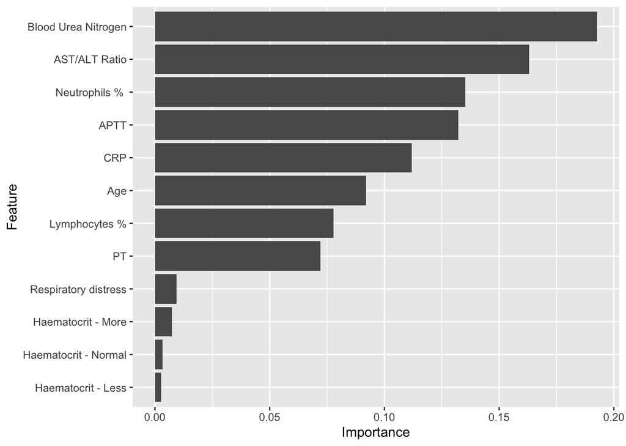

#### Model results

##### AUC

```
##
## Call:
## roc.default(response = mixmodel_dtest_20$Outcome, predictor = mixmodel_pred_prob$DEATH,     levels = c("ALIVE", "DEATH"), direction = c("<"))
##
## Data: mixmodel_pred_prob$DEATH in 90 controls (mixmodel_dtest_20$Outcome ALIVE) < 12 cases (mixmodel_dtest_20$Outcome DEATH).
## Area under the curve: 0.8787
```

##### Predictivy values

```
## Confusion Matrix and Statistics
##
##           Reference
## Prediction ALIVE DEATH
##      ALIVE    86     7
##      DEATH     4     5
##
##                Accuracy : 0.8922
##                  95% CI : (0.8152, 0.9449)
##     No Information Rate : 0.8824
##     P-Value [Acc > NIR] : 0.4544
##
##                   Kappa : 0.4174
##
##  Mcnemar's Test P-Value : 0.5465
##
##             Sensitivity : 0.41667
##             Specificity : 0.95556
##          Pos Pred Value : 0.55556
##          Neg Pred Value : 0.92473
##              Prevalence : 0.11765
##          Detection Rate : 0.04902
##    Detection Prevalence : 0.08824
##       Balanced Accuracy : 0.68611
##
##        'Positive' Class : DEATH
##
```

Confidence intervals of Sensitivity and Specificity (Note that Outcome + means ‘DEATH’)

|  | Estimate | Lower Interval | Upper Interval |
| --- | --- | --- | --- |
| Sensitivity | 0.417 | 0.152 | 0.723 |
| Specificity | 0.956 | 0.890 | 0.988 |
| Positive Predictive Value | 0.556 | 0.212 | 0.863 |
| Negative Predictive Value | 0.925 | 0.851 | 0.969 |

### Oversampled model

Train and test datasets created previoysly using `upSample` from `caret` package and the `createDataPartition(as.factor(Farvadin_2$Outcome), p=0.80, list=FALSE)` also from the `caret` package.

Train data (80%)

```r
dtrain_over_80 <- readRDS("Farvadin_2_balanced_over_train_80.Rda")  %>%
  mutate(Outcome = recode(Outcome, "0" = "ALIVE", "1" = "DEATH"))
summary(dtrain_over_80$Outcome)
```

```
## ALIVE DEATH
##   363   363
```

Test data (20%)

```r
dtest_over_20 <- readRDS("Farvadin_2_balanced_over_test_20.Rda") %>%
  mutate(Outcome = recode(Outcome, "0" = "ALIVE", "1" = "DEATH"))
summary(dtest_over_20$Outcome)
```

```
## ALIVE DEATH
##    90    90
```

#### Loading data

```r
dtrain_over_80 %>%
  select(Outcome,
         PT,
         Neutrophilspercent,
         lymphocytespercent,
         CatHaematocrit,
         Age,
         CRP,
         Respiratorydistress1,
         ASTALTRatio,
         APTT,
         BloodUreaNitrogen) %>%
  # filter(complete.cases(.)) %>%
  fastDummies::dummy_columns(select_columns = c("CatHaematocrit", "CatHB"),
                             ignore_na = T,
                             remove_selected_columns = T) -> mixmodel_dtrain_over_80
dtest_over_20 %>%
  select(Outcome,
         PT,
         Neutrophilspercent,
         lymphocytespercent,
         CatHaematocrit,
         Age,
         CRP,
         Respiratorydistress1,
         ASTALTRatio,
         APTT,
         BloodUreaNitrogen) %>%
  # filter(complete.cases(.)) %>%
  fastDummies::dummy_columns(select_columns = c("CatHaematocrit", "CatHB"),
                             ignore_na = T,
                             remove_selected_columns = T) -> mixmodel_dtest_over_20
```

#### Model trains

```r
library(doParallel)
cl <- makePSOCKcluster(detectCores())
registerDoParallel(cl)
mixmodel_over_train_control = trainControl(
  method = "cv",
  number = 5,
  verboseIter = FALSE,
  returnData = FALSE,
  returnResamp = "all", # save losses across all models
  classProbs = TRUE, # set to TRUE for AUC to be computed
  summaryFunction = twoClassSummary,
  allowParallel = TRUE
)

mixmodel_over_tune_grid = expand.grid(
  nrounds = 5000,
  max_depth = c(2, 4, 6, 8, 10),
  eta=c(0.5, 0.3, 0.1, 0.07),
  gamma = c(0, 0.01),
  colsample_bytree=c(1, 0.5),
  min_child_weight=1,
  subsample=c(1, 0.5)
)

# Recode https://stackoverflow.com/a/44131491/9664743
set.seed(0)
mixmodel_over_caret_model = train(
  x = as.matrix(mixmodel_dtrain_over_80 %>% select(-Outcome)),
  y = mixmodel_dtrain_over_80$Outcome,
  trControl = mixmodel_over_train_control,
  tuneGrid = mixmodel_over_tune_grid,
  metric= "ROC",
  method = "xgbTree"
)
registerDoSEQ()
mixmodel_over_caret_model$bestTune
```

```
##    nrounds max_depth eta gamma colsample_bytree min_child_weight subsample
## 91    5000         4 0.3     0                1                1       0.5
```

```r
saveRDS(mixmodel_over_caret_model, file="mixmodel_over_caret_train_20121204.model")
```

#### Variables importance

```
## xgbTree variable importance
##
##                       Overall
## lymphocytespercent   0.155644
## BloodUreaNitrogen    0.144569
## APTT                 0.134912
## Neutrophilspercent   0.127320
## Age                  0.114644
## ASTALTRatio          0.113001
## CRP                  0.093424
## PT                   0.073857
## CatHaematocrit_0     0.016608
## CatHaematocrit_2     0.013890
## Respiratorydistress1 0.009435
## CatHaematocrit_1     0.002696
```

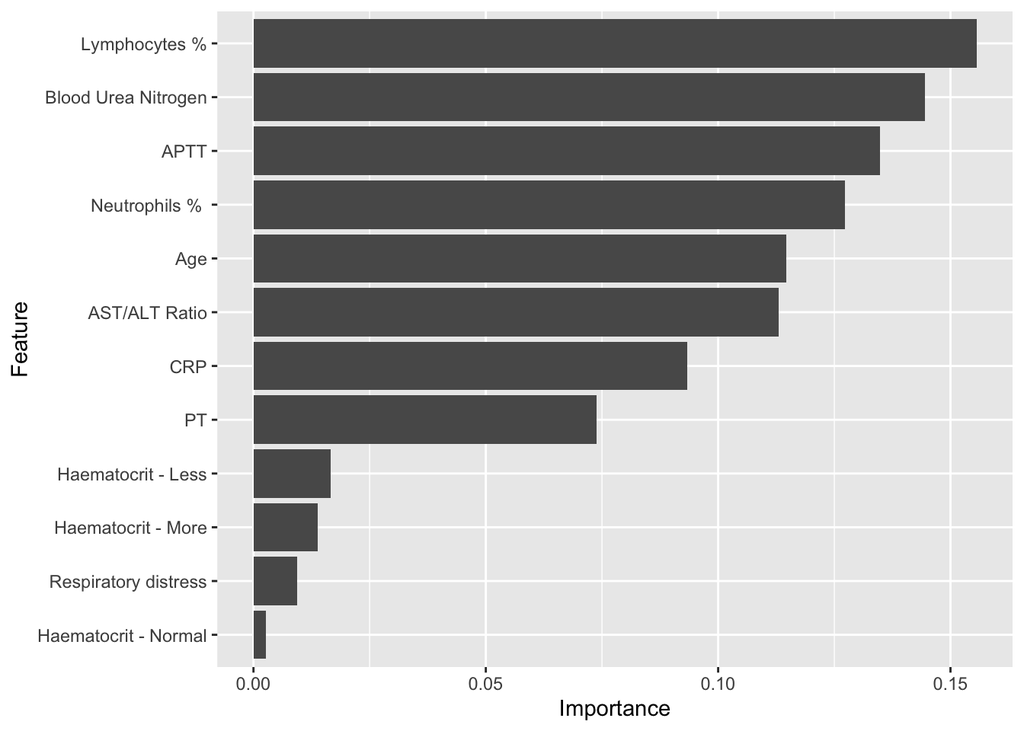

#### Model results using oversample TEST set

##### AUC

```
##
## Call:
## roc.default(response = mixmodel_dtest_over_20$Outcome, predictor = mixmodel_over_pred_prob$DEATH,     levels = c("ALIVE", "DEATH"), direction = c("<"))
##
## Data: mixmodel_over_pred_prob$DEATH in 90 controls (mixmodel_dtest_over_20$Outcome ALIVE) < 90 cases (mixmodel_dtest_over_20$Outcome DEATH).
## Area under the curve: 0.989
```

##### Predictivy values

```
## Confusion Matrix and Statistics
##
##           Reference
## Prediction ALIVE DEATH
##      ALIVE    84     0
##      DEATH     6    90
##
##                Accuracy : 0.9667
##                  95% CI : (0.9289, 0.9877)
##     No Information Rate : 0.5
##     P-Value [Acc > NIR] : < 2e-16
##
##                   Kappa : 0.9333
##
##  Mcnemar's Test P-Value : 0.04123
##
##             Sensitivity : 1.0000
##             Specificity : 0.9333
##          Pos Pred Value : 0.9375
##          Neg Pred Value : 1.0000
##              Prevalence : 0.5000
##          Detection Rate : 0.5000
##    Detection Prevalence : 0.5333
##       Balanced Accuracy : 0.9667
##
##        'Positive' Class : DEATH
##
```

Confidence intervals of Sensitivity and Specificity (Note that Outcome + means ‘DEATH’)

|  | Estimate | Lower Interval | Upper Interval |
| --- | --- | --- | --- |
| Sensitivity | 1.000 | 0.960 | 1.000 |
| Specificity | 0.933 | 0.861 | 0.975 |
| Positive Predictive Value | 0.938 | 0.869 | 0.977 |
| Negative Predictive Value | 1.000 | 0.957 | 1.000 |

#### Model results using all data

##### AUC

```
##
## Call:
## roc.default(response = Farvadin_2_full_data$Outcome, predictor = mixmodel_over_full_data_pred_prob$DEATH,     levels = c("ALIVE", "DEATH"), direction = c("<"))
##
## Data: mixmodel_over_full_data_pred_prob$DEATH in 453 controls (Farvadin_2_full_data$Outcome ALIVE) < 60 cases (Farvadin_2_full_data$Outcome DEATH).
## Area under the curve: 0.998
```

##### Predictivy values

```
## Confusion Matrix and Statistics
##
##           Reference
## Prediction ALIVE DEATH
##      ALIVE   446     0
##      DEATH     7    60
##
##                Accuracy : 0.9864
##                  95% CI : (0.9721, 0.9945)
##     No Information Rate : 0.883
##     P-Value [Acc > NIR] : < 2e-16
##
##                   Kappa : 0.9371
##
##  Mcnemar's Test P-Value : 0.02334
##
##             Sensitivity : 1.0000
##             Specificity : 0.9845
##          Pos Pred Value : 0.8955
##          Neg Pred Value : 1.0000
##              Prevalence : 0.1170
##          Detection Rate : 0.1170
##    Detection Prevalence : 0.1306
##       Balanced Accuracy : 0.9923
##
##        'Positive' Class : DEATH
##
```

Confidence intervals of Sensitivity and Specificity (Note that Outcome + means ‘DEATH’)

|  | Estimate | Lower Interval | Upper Interval |
| --- | --- | --- | --- |
| Sensitivity | 1.000 | 0.940 | 1.000 |
| Specificity | 0.985 | 0.968 | 0.994 |
| Positive Predictive Value | 0.896 | 0.797 | 0.957 |
| Negative Predictive Value | 1.000 | 0.992 | 1.000 |

### Undersample model

Train and test datasets created previoysly using `downSample` from `caret` package and the `createDataPartition(as.factor(Farvadin_2$Outcome), p=0.80, list=FALSE)` also from the `caret` package.

Train data (80%)

```
## ALIVE DEATH
##    48    48
```

Test data (20%)

```
## ALIVE DEATH
##    12    12
```

#### Model trains

```
##     nrounds max_depth eta gamma colsample_bytree min_child_weight subsample
## 102    5000         6 0.3  0.01              0.5                1         1
```

```r
saveRDS(mixmodel_under_caret_model, file="mixmodel_under_caret_train_20121204.model")
```

##### Variables importance

```
## xgbTree variable importance
##
##                      Overall
## Neutrophilspercent   0.35931
## Age                  0.21193
## BloodUreaNitrogen    0.15784
## ASTALTRatio          0.09336
## APTT                 0.06541
## lymphocytespercent   0.04389
## CRP                  0.03440
## PT                   0.01741
## CatHaematocrit_0     0.01351
## Respiratorydistress1 0.00293
## CatHaematocrit_2     0.00000
## CatHaematocrit_1     0.00000
```

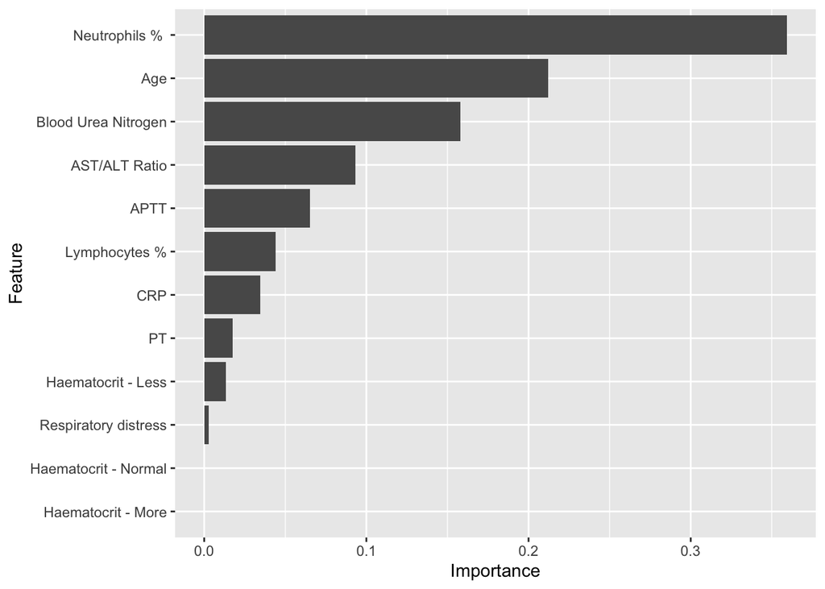

##### AUC

```
##
## Call:
## roc.default(response = mixmodel_dtest_under_20$Outcome, predictor = mixmodel_under_pred_prob$DEATH,     levels = c("ALIVE", "DEATH"), direction = c("<"))
##
## Data: mixmodel_under_pred_prob$DEATH in 12 controls (mixmodel_dtest_under_20$Outcome ALIVE) < 12 cases (mixmodel_dtest_under_20$Outcome DEATH).
## Area under the curve: 0.8472
```

##### Predictivy values

```
## Confusion Matrix and Statistics
##
##           Reference
## Prediction ALIVE DEATH
##      ALIVE     9     2
##      DEATH     3    10
##
##                Accuracy : 0.7917
##                  95% CI : (0.5785, 0.9287)
##     No Information Rate : 0.5
##     P-Value [Acc > NIR] : 0.003305
##
##                   Kappa : 0.5833
##
##  Mcnemar's Test P-Value : 1.000000
##
##             Sensitivity : 0.8333
##             Specificity : 0.7500
##          Pos Pred Value : 0.7692
##          Neg Pred Value : 0.8182
##              Prevalence : 0.5000
##          Detection Rate : 0.4167
##    Detection Prevalence : 0.5417
##       Balanced Accuracy : 0.7917
##
##        'Positive' Class : DEATH
##
```

Confidence intervals of Sensitivity and Specificity (Note that Outcome + means ‘DEATH’)

|  | Estimate | Lower Interval | Upper Interval |
| --- | --- | --- | --- |
| Sensitivity | 0.833 | 0.516 | 0.979 |
| Specificity | 0.750 | 0.428 | 0.945 |
| Positive Predictive Value | 0.769 | 0.462 | 0.950 |
| Negative Predictive Value | 0.818 | 0.482 | 0.977 |

#### Model results using all data

##### AUC

```
##
## Call:
## roc.default(response = Farvadin_2_full_data$Outcome, predictor = mixmodel_under_full_data_pred_prob$DEATH,     levels = c("ALIVE", "DEATH"), direction = c("<"))
##
## Data: mixmodel_under_full_data_pred_prob$DEATH in 453 controls (Farvadin_2_full_data$Outcome ALIVE) < 60 cases (Farvadin_2_full_data$Outcome DEATH).
## Area under the curve: 0.918
```

##### Predictivy values

```
## Confusion Matrix and Statistics
##
##           Reference
## Prediction ALIVE DEATH
##      ALIVE   337     2
##      DEATH   116    58
##
##                Accuracy : 0.77
##                  95% CI : (0.7311, 0.8057)
##     No Information Rate : 0.883
##     P-Value [Acc > NIR] : 1
##
##                   Kappa : 0.3895
##
##  Mcnemar's Test P-Value : <2e-16
##
##             Sensitivity : 0.9667
##             Specificity : 0.7439
##          Pos Pred Value : 0.3333
##          Neg Pred Value : 0.9941
##              Prevalence : 0.1170
##          Detection Rate : 0.1131
##    Detection Prevalence : 0.3392
##       Balanced Accuracy : 0.8553
##
##        'Positive' Class : DEATH
##
```

Confidence intervals of Sensitivity and Specificity (Note that Outcome + means ‘DEATH’)

|  | Estimate | Lower Interval | Upper Interval |
| --- | --- | --- | --- |
| Sensitivity | 0.967 | 0.885 | 0.996 |
| Specificity | 0.744 | 0.701 | 0.784 |
| Positive Predictive Value | 0.333 | 0.264 | 0.409 |
| Negative Predictive Value | 0.994 | 0.979 | 0.999 |

### Oversample ROSE model

Train and test datasets created previoysly using `ROSE` from `ROSE` package and the `createDataPartition(as.factor(Farvadin_2$Outcome), p=0.80, list=FALSE)` also from the `caret` package.

Train data (80%)

```
## ALIVE DEATH
##    66    61
```

Test data (20%)

```
## ALIVE DEATH
##    16    15
```

#### Model trains

```
##    nrounds max_depth  eta gamma colsample_bytree min_child_weight subsample
## 23    5000         6 0.07  0.01                1                1       0.5
```

```r
saveRDS(mixmodel_ROSE_caret_model, file="mixmodel_ROSE_caret_train_20121204.model")
```

##### Variables importance

```
## xgbTree variable importance
##
##                      Overall
## PT                   0.36791
## Neutrophilspercent   0.11763
## BloodUreaNitrogen    0.09194
## APTT                 0.08906
## ASTALTRatio          0.07562
## CRP                  0.06195
## Age                  0.05177
## lymphocytespercent   0.04336
## Respiratorydistress1 0.04020
## CatHaematocrit_0     0.03106
## CatHaematocrit_1     0.02951
## CatHaematocrit_2     0.00000
```

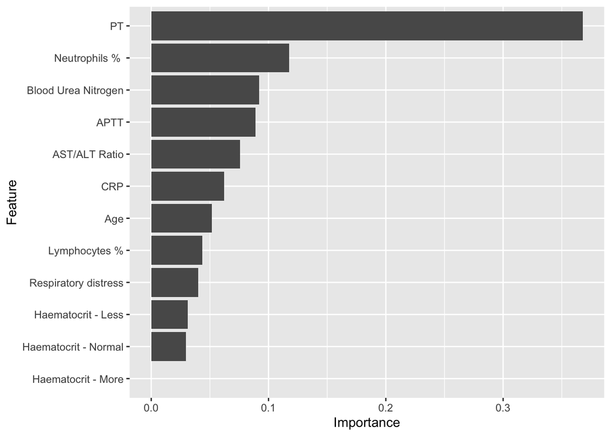

#### Model results using oversample TEST set

##### AUC

```
##
## Call:
## roc.default(response = mixmodel_dtest_ROSE_20$Outcome, predictor = mixmodel_ROSE_pred_prob$DEATH,     levels = c("ALIVE", "DEATH"), direction = c("<"))
##
## Data: mixmodel_ROSE_pred_prob$DEATH in 16 controls (mixmodel_dtest_ROSE_20$Outcome ALIVE) < 15 cases (mixmodel_dtest_ROSE_20$Outcome DEATH).
## Area under the curve: 0.9958
```

##### Predictivy values

```
## Confusion Matrix and Statistics
##
##           Reference
## Prediction ALIVE DEATH
##      ALIVE    16     1
##      DEATH     0    14
##
##                Accuracy : 0.9677
##                  95% CI : (0.833, 0.9992)
##     No Information Rate : 0.5161
##     P-Value [Acc > NIR] : 3.746e-08
##
##                   Kappa : 0.9353
##
##  Mcnemar's Test P-Value : 1
##
##             Sensitivity : 0.9333
##             Specificity : 1.0000
##          Pos Pred Value : 1.0000
##          Neg Pred Value : 0.9412
##              Prevalence : 0.4839
##          Detection Rate : 0.4516
##    Detection Prevalence : 0.4516
##       Balanced Accuracy : 0.9667
##
##        'Positive' Class : DEATH
##
```

Confidence intervals of Sensitivity and Specificity (Note that Outcome + means ‘DEATH’)

|  | Estimate | Lower Interval | Upper Interval |
| --- | --- | --- | --- |
| Sensitivity | 0.933 | 0.681 | 0.998 |
| Specificity | 1.000 | 0.794 | 1.000 |
| Positive Predictive Value | 1.000 | 0.768 | 1.000 |
| Negative Predictive Value | 0.941 | 0.713 | 0.999 |

#### Model results using all data

##### AUC

```
##
## Call:
## roc.default(response = Farvadin_2_full_data$Outcome, predictor = mixmodel_ROSE_full_data_pred_prob$DEATH,     levels = c("ALIVE", "DEATH"), direction = c("<"))
##
## Data: mixmodel_ROSE_full_data_pred_prob$DEATH in 453 controls (Farvadin_2_full_data$Outcome ALIVE) < 60 cases (Farvadin_2_full_data$Outcome DEATH).
## Area under the curve: 0.746
```

##### Predictivy values

```
## Confusion Matrix and Statistics
##
##           Reference
## Prediction ALIVE DEATH
##      ALIVE   362    28
##      DEATH    91    32
##
##                Accuracy : 0.768
##                  95% CI : (0.729, 0.804)
##     No Information Rate : 0.883
##     P-Value [Acc > NIR] : 1
##
##                   Kappa : 0.228
##
##  Mcnemar's Test P-Value : 1.32e-08
##
##             Sensitivity : 0.5333
##             Specificity : 0.7991
##          Pos Pred Value : 0.2602
##          Neg Pred Value : 0.9282
##              Prevalence : 0.1170
##          Detection Rate : 0.0624
##    Detection Prevalence : 0.2398
##       Balanced Accuracy : 0.6662
##
##        'Positive' Class : DEATH
##
```

Confidence intervals of Sensitivity and Specificity (Note that Outcome + means ‘DEATH’)

|  | Estimate | Lower Interval | Upper Interval |
| --- | --- | --- | --- |
| Sensitivity | 0.533 | 0.400 | 0.663 |
| Specificity | 0.799 | 0.759 | 0.835 |
| Positive Predictive Value | 0.260 | 0.185 | 0.347 |
| Negative Predictive Value | 0.928 | 0.898 | 0.952 |